# supp

- Each method makes a different mathematical assumption
- Same data yields **different effect sizes** — sometimes opposite direction
- No consensus on which is correct

Sanchis-Segura et al., 2020 · Sanfilipo et al., 2004 · O’Brien et al., 2011 · de Jong et al., 2017

Chapter 5 · ICV independence

HVR halves the ICV correlation

| Measure | r with ICV |
| --- | --- |
| **Raw HC** | ≈ **+0.60** |
| **HC proportions** | ≈ **−0.39** (over-corrected) |
| **HC stereotaxic** | ≈ 0 |
| **HC residualized** | = 0 (by construction) |
| **HVR** | ≈ **−0.25** |

**Honest framing**

- HVR is **less confounded** than raw HC — not strictly zero
- Negative r is the LV component scaling
- HVR retains biologically meaningful variation that residualization erases

de Jong et al., 2017 · Pintzka et al., 2015

Chapter 5 · The headline result

HC sex differences reverse across methods — HVR doesn’t

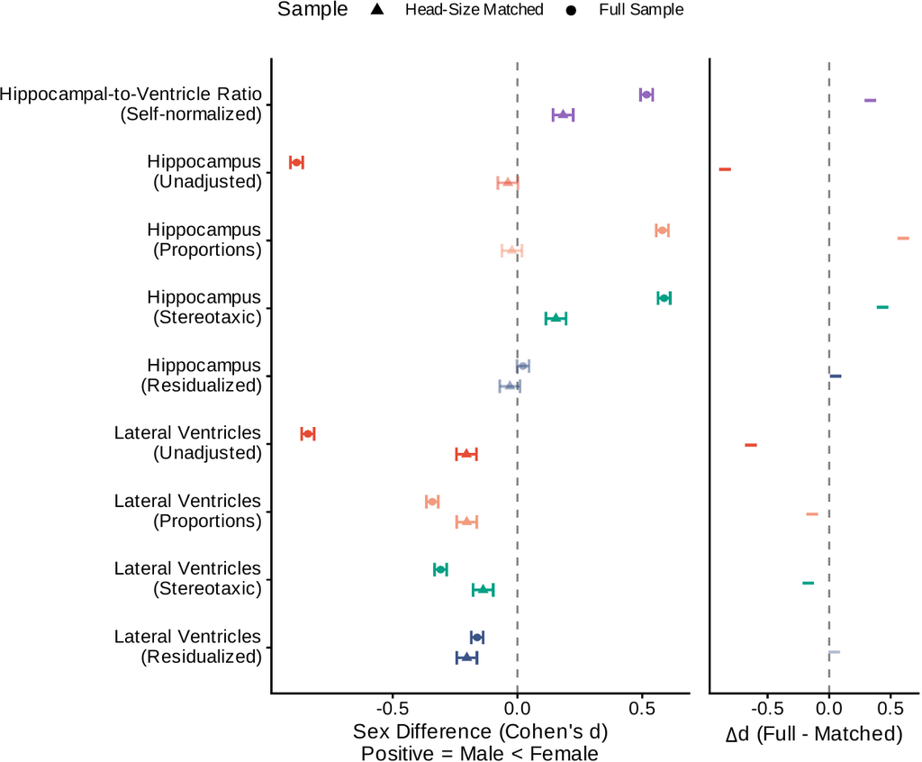

HC d swings **1.5 SD** across methods (−0.89 raw → +0.58 proportions)  
HVR holds at d ≈ **+0.52** (female advantage); LV stays negative

Chapter 5 · ICV-matched test

Matching collapses HC effects; HVR persists

**Matching construction**

- 1:1 optimal Mahalanobis
- Age ±1 yr
- ICV ±25 cc (~0.3 SD)
- 4,750 pairs (9,500 total)

**Results**

| Measure | Full d | Matched d |
| --- | --- | --- |
| HC raw | −0.89 | ≈ 0 |
| LV raw | persists | attenuates |
| **HVR** | +0.52 | **+0.19** |

**Interpretation**

- HC sex difference IS the head-size confound
- HVR sex difference is **not** a head-size artifact

**This is the geometric proof** the chapter rests on.

Ho et al., 2011 · Pintzka et al., 2015 · Voevodskaya et al., 2014

Chapter 5 · Effect size defense

Is d = 0.18 meaningful?

Yes — biology, not just power

d = 0.18

HVR sex difference in 4,750 ICV-matched pairs

With ICV equated, the effect is pure biology.  
Widens with age (≈ 0.13 at 45–55 → ≈ 0.30 at 75+). Survives at matched-sample N = 9,500, where power = 99% to detect d = 0.10.

Cohen, 2013

Chapter 5 · Age × sex

Males show 1.7× steeper HVR decline

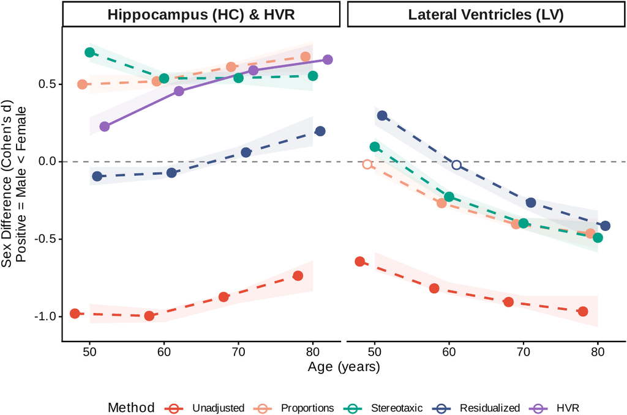

Male HVR slope sits at **1.7×** female — between HC (1.4×) and LV (2.0×)  
Consistent with HVR capturing both atrophy and expansion (*p* < 10⁻⁵⁰)

Chapter 5 · Design caveat

Cross-sectional ≠ longitudinal

**What cross-sectional can’t prove**

- Individual within-subject decline
- Cohort effects (e.g., post-menopausal hormones)

**Temporal stability check**

- 2.7-year ses-2 / ses-3 retest in N = 2,935
- HVR ICC > 0.93
- HC + LV ICCs similar

**Longitudinal HVR** explored in Ch6 (ADNI A+).

**Defensible because**

- Pseudo-trajectories from large cross-section approximate population trajectories in many studies
- High retest ICC supports temporal stability
- LGCM in Ch6 directly tests longitudinal HVR change

Chapter 5 · Normative centiles

Sex-specific  
HVR centile curves

Females (red), All, Males (blue);  
HVR, HC, LV

**GAMLSS spec**

μ = cubic spline(age) + site random intercept;  
σ also age-varying.

**Fit + selection**

80/20 train/test, refit on full data;  
**BCCG distribution** selected by AIC/BIC.

Centiles (5/10/25/50/75/90/95)  
generated for ages 45–82 by sex.

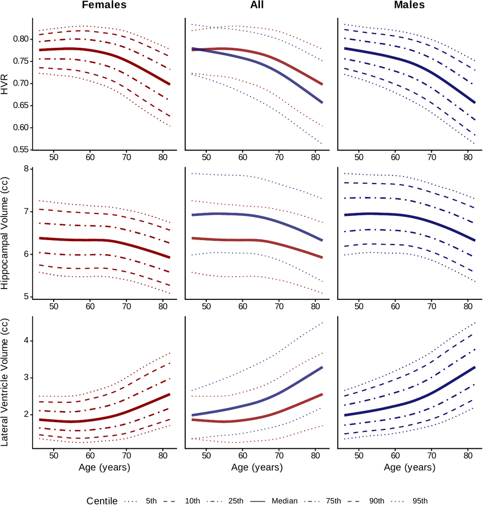

Chapter 5 · Methodology defense

Why GAMLSS, not Bayesian / PCN / ComBat?

**GAMLSS pros**

- Well-established (Rigby & Stasinopoulos 2005)
- Used in **Bethlehem 2022 brain charts**
- Models μ + σ + ν jointly
- Transparent coefficients for **external transfer**

**Alternatives & why not**

- **Marquand PCN**: more flexible for site harmonization, but requires Bayesian priors + reference pretraining (UKB is the reference here)
- **ComBat-GAM**: harmonizes site, not normative centiles
- **hbr / Bayesian hierarchical**: similar tradeoffs

Rigby & Stasinopoulos, 2005 · Bethlehem et al., 2022 · Ge et al., 2024

Chapter 5 · Calibration

Centile model is well-calibrated

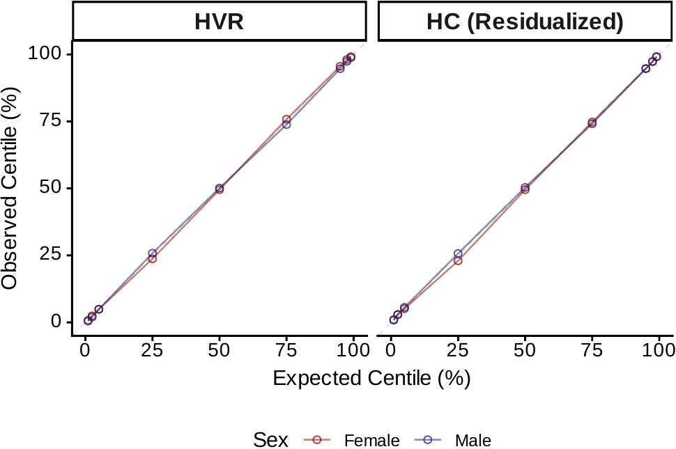

Held-out 20% test set: observed proportions below each nominal centile vs expected. Points on diagonal = perfectly calibrated.

Chapter 5 · Cognitive measurement

Bifactor SEM extracts g + domain factors

**12 UKB cognitive indicators**

- Memory: PM, NM, prospective memory
- Speed: RT, TMA, SDS
- Executive function: TMB, tower
- Reasoning + verbal + numeric

**Bifactor structure**

- **g** loads on all 12
- **Memory_s** loads on 3 memory items
- **Speed_s** loads on 3 speed items
- All factors orthogonal

**Caveats**

- UKB battery is touchscreen, briefer than ADNI’s neuropsych
- Memory_s collapsed in fit (common in bifactor; Eid 2017)
- Speed_s + g retained as the analytic factors

Rosseel et al., 2012 (lavaan) · Eid et al., 2017 · Burns 2020

Chapter 5 · Measurement invariance

Strict invariance across sex

| Step | ΔCFI | ΔRMSEA | Verdict |
| --- | --- | --- | --- |
| Configural | — (CFI = 0.963; RMSEA = 0.059) | — | **fit** |
| Metric (loadings) | **−0.001** | **−0.004** | **supported** |
| Scalar (intercepts) | **−0.006** | **+0.002** | **supported** |
| Strict (residuals) | **−0.001** | **−0.002** | **supported** |

All ΔCFI within ±0.01 and ΔRMSEA within ±0.015 → strict invariance holds → sex-stratified SEM paths directly comparable.

Cheung & Rensvold, 2002 · Chen 2007 · Putnick & Bornstein, 2016

Chapter 5 · Functional validity

HVR predicts g comparably to HC

| Predictor → g | β (95% CI) |
| --- | --- |
| **HC raw** | ≈ 0.055 [0.032, 0.078] |
| **HC residualized** | ≈ 0.039 [0.019, 0.059] |
| **HVR** | ≈ **0.060 [0.038, 0.081]** |

HVR’s brain–cognition association is comparable to (or numerically stronger than) HC-based measures. CIs overlap.

Chapter 5 · Sex-stratified paths

HVR predicts cognition in males where HC_res doesn’t

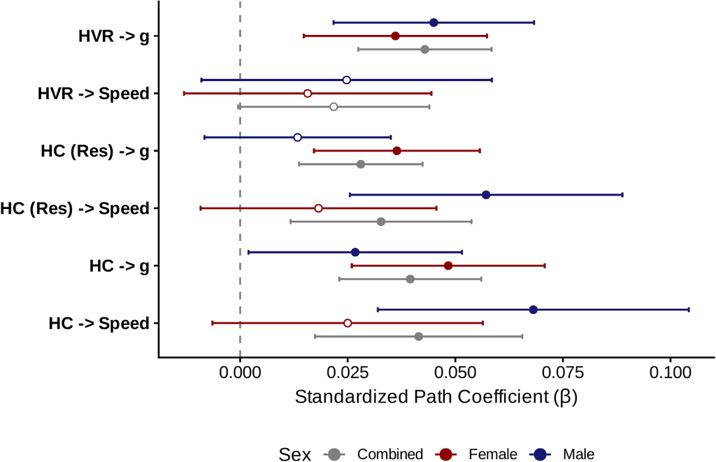

HVR → g is significant in **both sexes** (F β = 0.036, M β = 0.045)  
HC<sub>RES</sub> → g is significant only in females (M β = 0.013, n.s.)

Zheng et al., 2017 · Jockwitz et al., 2024 · Bachmann et al., 2023

Chapter 5 · Sensitivity analyses

Site, hemisphere, psychiatric history

**Site**

ICC = 0.004–0.012  
< 1.5% variance  
— minimal contribution

**Hemisphere**

LV: d_L = 0.477, d_R = 0.481  
HC<sub>RES</sub>: d_L = −0.143, d_R = −0.160  
HVR: d_R = +0.05, d_L = −0.01  
— effectively symmetric

**Psychiatric history**

F-codes sensitivity (N = 30,032)  
HVR: Δd = 0.002  
HC raw: Δd = −0.001  
— max |Δd| = 0.009

Fry et al., 2017

Chapter 5 · Distribution visualization

Density overlays:  
full vs matched

Females (red) vs males (blue)

Density overlays of **HC, LV, HVR**  
× 4 adjustment methods.

**Left** full sample

**Right** ICV-matched sub-sample

In the matched column  
HC distributions converge  
while HVR retains separation —  
visual companion to the effect-size analysis.

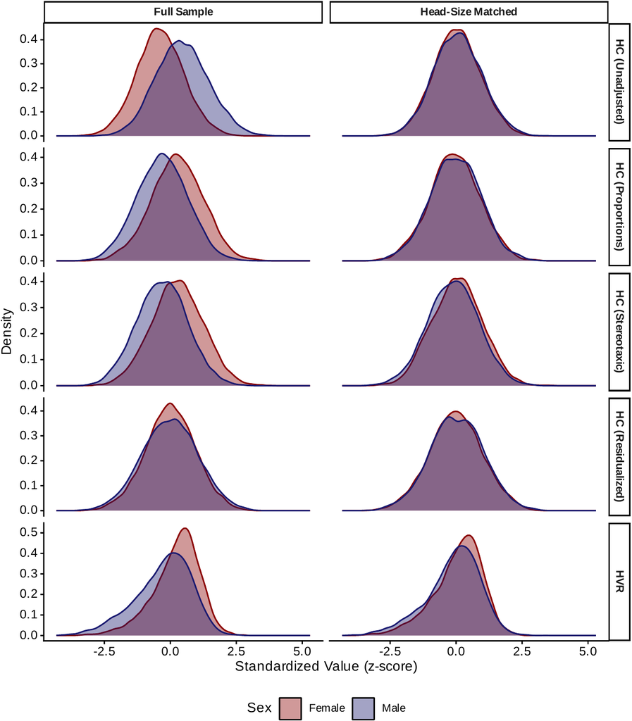

Chapter 5 · Literature comparison

How does this compare to Bethlehem 2022?

**Prior work**

- **Bethlehem 2022**: HC + total ventricles, lifespan charts — no HVR, no sex stratification for headline
- **Ge 2024**: sex-specific norms — not for HVR
- **Dima 2022** (ENIGMA): subcortical norms — no HVR

**This chapter’s contribution**

- HVR-specific norms
- Sex-stratified throughout
- Transfer coefficients published for external cohorts
- Used in Ch6 to z-score ADNI participants

Bethlehem et al., 2022 · Ge et al., 2024 · Dima et al., 2022 · Coupé et al., 2019

Chapter 5 · Generalizability

UKB volunteer bias — what does it mean?

**Fry 2017 documented**

- UKB volunteers ~5% more likely to be highly educated
- Less obese, less likely to smoke
- Disproportionately white

**Direction of bias**

- Healthy-volunteer effect → **attenuates** clinical effect sizes
- Sex-difference findings are conservative

**Mitigations**

- Centiles transfer well to disease-enriched cohorts (Ch6 demonstrates)
- Replication in more diverse cohorts (WRAP, AIBL) is future work
- Sample size compensates for some bias

Fry et al., 2017

Chapter 5 · Limitations

What this chapter does not claim

**Design**

- Cross-sectional (longitudinal in Ch6)
- HVR conflates HC + LV in a single value
- UKB volunteer bias

**Measurement model**

- Memory_s factor collapse
- lavaan doesn’t support cluster + multigroup simultaneously
- Power-corrected proportions not tested

**Data**

- APOE not available in UKB Application 45551

**Mitigations**

- Ses-3 retest validates temporal stability
- Speed_s + g retained as analytic factors
- Site ICCs negligible
- Ch6 tests UKB norms in ADNI

Chapter 5 · Non-linear aging

HVR captures accelerating decline that HC misses

**Quadratic age coefficients (SEM)**

| Measure | β<sub>age²</sub> | p |
| --- | --- | --- |
| HVR | **−0.134** | < 0.001 |
| HC residualized | **−0.075** | < 0.001 |
| HC (raw) | not estimable | — |

All quadratic age effects are **negative** — decline accelerates with age.

**Why HVR accelerates more**

- HVR captures **both** HC atrophy and ventricular expansion
- Both processes accelerate at older ages
- HC residualization removes the ventricular signal

**Why raw HC has no quadratic term**

- HC + ICV + age² produces multicollinearity
- Linear-only specification required for raw HC

Chapter 5 · Temporal stability

HVR ICC = 0.93 — stable over 2.7 years

| Measure | r | ICC |
| --- | --- | --- |
| HC | 0.964 | 0.959 |
| LV | 0.958 | 0.946 |
| **HVR** | **0.952** | **0.933** |

**Setup**

- ses-2 / ses-3 retest, N = 2,935
- Mean follow-up: 2.7 years (SD 1.1)

**Why HVR is slightly lower**

- HVR conflates two age-changing processes — true within-subject change reduces apparent reliability
- HC and LV measure single structures and drift less in absolute terms

**All > 0.93 = excellent**

HVR remains a stable individual marker;  
the small ICC gap reflects biology,  
not measurement noise.

Koo & Li, 2016

Chapter 5 · Biological reason

HC scales hypoallometrically with ICV (α = 0.60)

**Scaling exponents**

- Hippocampus: **α = 0.60**  
  (hypoallometric — grows slower than ICV)
- Lateral ventricles: **α ≈ 1.0**  
  (isometric with ICV)

**Consequence**

Proportional correction (HC / ICV) **over-corrects** because HC and ICV don’t scale linearly.

**Why HVR-ICV ≠ 0**

- HC scales as ICV<sup>0.60</sup>; LV scales as ICV<sup>1.0</sup>
- HVR ratio inherits these geometries
- Residual HVR-ICV r ≈ −0.25 is biological signature, not artifact

**Take-away**

Allometric scaling explains *why* proportions over-correct  
and *why* HVR’s small ICV correlation makes sense.

de Jong et al., 2017 · Williams et al., 2021

Chapter 5 · Sex-differential cognition

Speed_s — males show structure–function; females don’t

**Pooled paths to Speed<sub>s</sub>**

| Predictor | β | p |
| --- | --- | --- |
| HC | 0.041 | <0.001 |
| HC residualized | 0.033 | 0.002 |
| HVR | 0.022 | 0.055 |

**Sex-stratified (males)**

- HC → Speed<sub>s</sub>: β = **0.068**
- HC<sub>RES</sub> → Speed<sub>s</sub>: β = **0.057**
- Females: **all n.s.**
- HVR → Speed<sub>s</sub>: n.s. both sexes

**Interpretation**

- Structure–speed link is **male-specific** in this sample
- HVR pattern same as g: predicts general factor, not Speed<sub>s</sub> specifically
- Memory<sub>s</sub> could not be reliably estimated (bifactor convergence)

**Why it matters**

Adds nuance to “HVR predicts cognition”:  
HVR predicts the general factor but  
not domain-specific Speed.

Chapter 5 · Limits of the female advantage

The female advantage is not universal

**The female-advantage hypothesis**

- **Cumulative estrogen exposure** — longer reproductive spans linked to younger brain ages (Luders 2025)
- Estrogen promotes hippocampal neurogenesis + synaptic plasticity (Jett 2022)

**The counter-evidence**

- Female APOE ε4 carriers show **faster** HC loss than male carriers in aMCI (Park 2025)
- Genetic risk can modulate or invert typical sex-differential patterns

**What Ch5 cannot do**

- APOE unavailable in this UKB application
- Pure cross-sectional — no longitudinal slopes
- Cannot test the sex × ε4 × age interaction directly here

**Ch6 picks this up** — ADNI A+ longitudinal cohort with APOE, FRS, and CVR_mimic.

Luders 2025 · Jett 2022 · Park 2025

Chapter 5 · Lateral ventricle story

LV — consistent male advantage; HVR lateralization

**LV sex difference (full sample)**

- Left: d = **0.48** (male > female)
- Right: d = **0.48** (male > female)
- ICV-matched subsample:  
  LV sex difference **attenuates** but does not collapse  
  (vs HC which collapses to ≈ 0)

**HVR lateralization (small)**

- Right: d = **+0.05** [0.03, 0.07] (sig, female adv)
- Left: d = −0.01 [−0.03, 0.02] (n.s.)
- Small effect, only right reaches significance

**Variance pattern (chapter)**

- Males show greater **ventricular variability** at older ages
- Consistent with heterogeneous aging in male LV trajectories

**Why surface this**

Committee may ask about LV separately.  
HVR captures LV’s male-larger signal  
as part of the ratio.

Mielke 2022 · Ferretti 2018

Chapter 5 · Why HVR fits quadratic age

HC + ICV + age² is not estimable — HVR is

**The collinearity**

- HC, ICV and age are correlated
- Adding age² to a model with HC and ICV produces unstable estimates
- HC unadjusted model uses **linear age only** per spec

**Why HVR avoids it**

- HVR is self-normalizing — **no ICV term needed**
- One fewer predictor in the design matrix
- Quadratic age can be estimated alongside HVR

**Not cherry-picking complexity**

- The model spec was decided by mathematics, not fit-hunting
- Each measure gets the most informative model its structure supports
- HC raw + ICV + age² → not estimable; HC<sub>RES</sub> + age² → fine; HVR + age² → fine

**Verdict**

Both HVR and HC<sub>RES</sub> support a quadratic age term;  
only raw HC (unadjusted with ICV as covariate) cannot.  
The asymmetry is a property of the design matrix,  
not a fitting advantage.

Chapter 6

Cardiovascular Risk  
+ HVR‑Cognitive Coupling

MIMIC-based age-adjusted CVR · LME + LGCM convergence  
Amyloid‑positive ADNI cohort

Chapter 6 · The thesis

Chapter 6 in one sentence

FRS effects on hippocampal decline reflect age —  
coupling itself is age‑independent

**a-path** (CVR → HVR slope)

- FRS: **significant**
- CVR<sub>mimic</sub>: null

**b-path** (HVR slope → cog slope)

- Both predictors: **significant**

**Implication**

- FRS appears to predict atrophy because age is inside FRS
- After MIMIC adjustment, that pathway disappears
- HVR–cognitive coupling **survives both** — a neurodegeneration signal, not vascular

Chapter 6 · Sample

Sample selection and parallel tracks

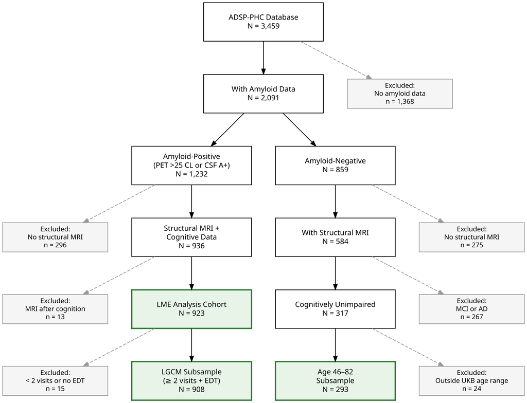

Left track — A+ analytic cohort. Right track — A−/CU sensitivity sample and UKB age-comparable subsample.

Chapter 6 · The motivating problem

Why FRS is age-confounded in elderly cohorts

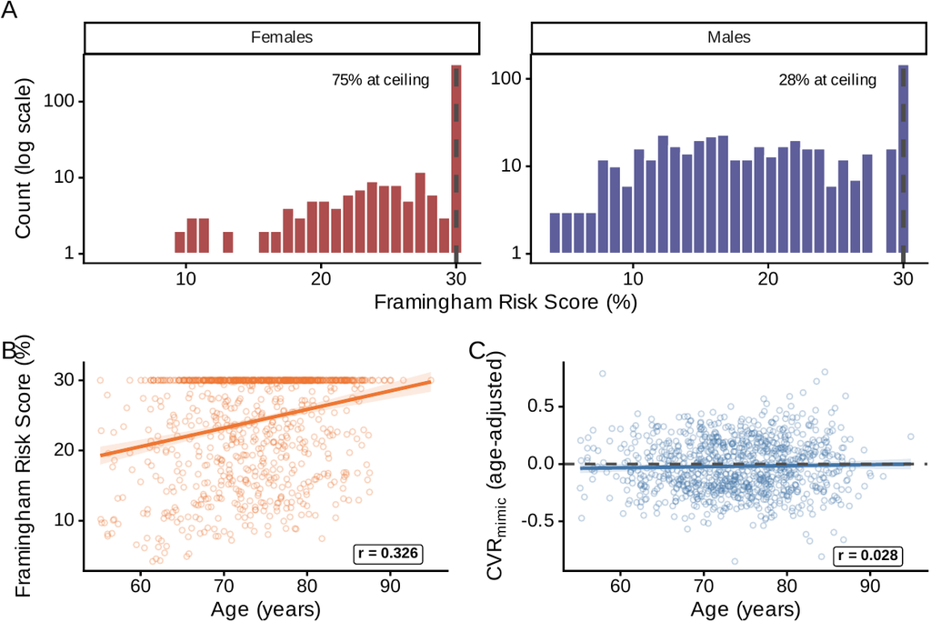

**Bottom line**

D’Agostino et al., 2008 · Koller et al., 2012 · Pencina et al., 2019

Chapter 6 · Methodology choice

Why MIMIC, not GAM / IV / covariate adjustment?

| Approach | Why not |
| --- | --- |
| **Covariate** | Age is *inside* FRS, not external |
| **GAM residual.** | Uses observed score (with error) |
| **IV** | No valid instrument |
| **MIMIC SEM** | **Adjusts at the latent level** |

**Why MIMIC**

- Partitions latent variance
- Removes age **at the latent** (not on noisy observed score)
- Preserves the CV construct after age is stripped out

Jöreskog & Goldberger, 1975 · Muthén, 1984 · Bollen, 1989

Chapter 6 · MIMIC specification

The MIMIC equation

**Structural model**

*CVR* = γ · *Age*<sub>*z*</sub> + ζ

**Measurement model**

*x*<sub>*j*</sub> = λ<sub>*j*</sub> · *CVR* + δ<sub>*j*</sub> , *j* = 1…5

**CVR<sub>mimic</sub> = ζ**  
residual after age regressed at latent level

**Specification notes**

- Correlated residuals: SBP ↔︎ Chol, SBP ↔︎ Creat (theory-driven)
- **γ = 0.125** (R² = 1.6%)
- Age explains a **tiny slice** of latent CVR
- CVR<sub>mimic</sub> is **age-orthogonal** by construction

Jöreskog & Goldberger, 1975 · Bollen, 1989

Chapter 6 · Indicator selection

Five indicators — what was kept, what was dropped

**Retained (5)**

- SBP
- Hypertension diagnosis
- Glucose
- Total cholesterol (negative loading — statin use)
- Creatinine

**Dropped**

- **BMI**: loading n.s. after correlated residuals
- **Diabetes / heart disease / stroke**: ADNI harmonization gives perfect tetrachoric correlations — degenerate
- **Smoking**: survivorship bias in elderly cohort
- **BP medication**: redundant with hypertension

Chapter 6 · Goodness of fit

MIMIC model fits well

| Index | Threshold | This model |
| --- | --- | --- |
| **CFI** | ≥ 0.95 | **≥ 0.95** |
| **TLI** | ≥ 0.95 | **≥ 0.95** |
| **RMSEA** | ≤ 0.06 | **≤ 0.06** |
| **SRMR** | ≤ 0.08 | **≤ 0.08** |

**Estimation**

- Robust ML (Satorra-Bentler) for non-normality
- Correlated residuals theory-driven, not MI-fishing
- All conventional cutoffs met

Rosseel, 2012 (lavaan) · Satorra & Bentler, 2001

Chapter 6 · CVR_mimic validation

CVR_mimic is age-orthogonal by construction

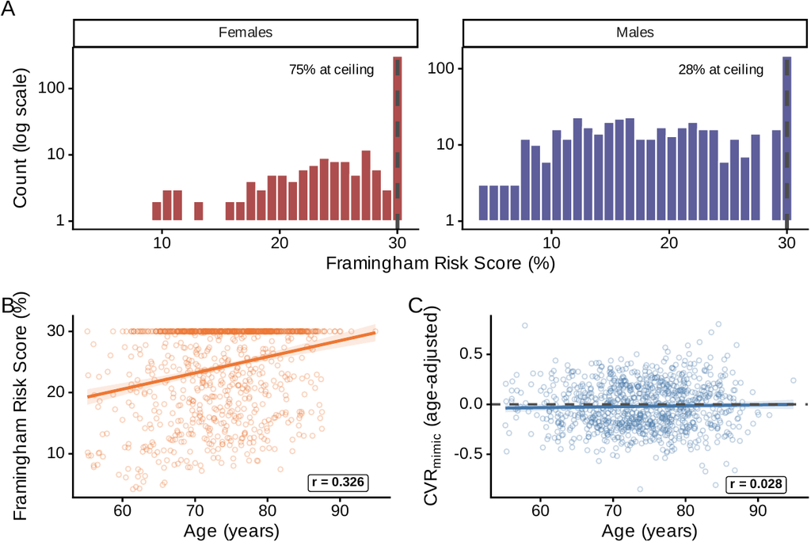

FRS climbs steeply with age (Panel B); CVR<sub>mimic</sub> stays flat (**r ≈ 0**, Panel C)  
CVR<sub>mimic</sub> ↔︎ FRS r ≈ 0.3–0.5: shared CV signal, distinct construct

Zhang & Yang, 2024

Chapter 6 · Measurement invariance

MIMIC invariance across sex

| Step | Status | Notes |
| --- | --- | --- |
| Configural | ✓ | model structure equal |
| Metric | ✓ | loadings equal |
| Scalar | partial | intercepts differ slightly |
| Strict | not required | residuals not constrained |

Metric invariance ✓ → sex-stratified path estimates directly comparable.

**Implication**

- Scalar partial invariance is fine for path comparisons (which use loadings, not intercepts)
- Sex-stratified analyses defensible at metric level

Satorra & Bentler, 2001

Chapter 6 · Time metric

EDT replaces calendar time as the LGCM clock

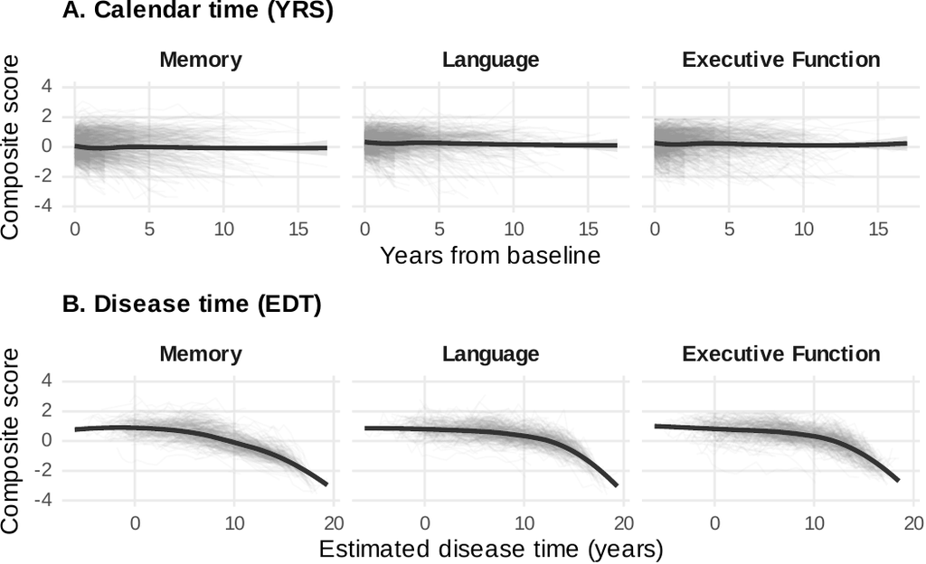

Calendar time hides the decline (Panel A) — disease stages pool out the trajectory  
EDT aligns participants on disease stage and the monotonic decline reappears (Panel B)

Raket, 2020 · Künel et al., 2021

Chapter 6 · EDT disclosure

EDT–cognition circularity: an honest disclosure

**The concern**

- ADAS-13 + MMSE feed **both** EDT and Memory / Language composites
- Could inflate EDT-cognition association artifactually

**Mitigations**

- Bifactor CFA dilutes any single item’s contribution
- EDT enters as **time axis only**, not as outcome
- Executive Function has minimal ADAS/MMSE overlap — same pattern emerges

**Verdict**

- Disclosed, mitigated
- Pattern holds in EF (least overlap)
- Future work: EDT from independent measures

Kang et al., 2023

Chapter 6 · LME specification

LME 3-way interaction model

**The equation**

*Cog*<sub>*it*</sub> = β₀ + *b*₀ᵢ + (β₁ + *b*₁ᵢ) · *YRS*  
+ linear (*YRS* × *CVR* × *HVR*) terms  
+ quadratic (*YRS*² × …) terms  
+ covariates (age, edu, APOE ε4)  
+ ε<sub>*it*</sub>

**Random**

intercept + slope per participant

**Stratification**

- **By sex** (separate male / female models)
- **By cognitive domain** (Memory, Language, Executive)
- **By CVR predictor** (FRS vs CVR_mimic)

Total: 12 LME tests (FRS + CVR_mimic) × 2 sex × 3 domain.

Bates et al., 2015 · Clayton et al., 2014

Chapter 6 · LME headline

FRS dominates; CVR_mimic mostly null

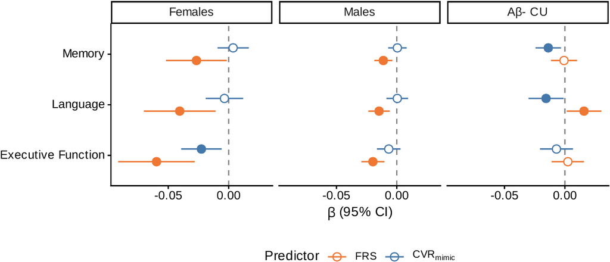

FRS 3-way interactions are significant across nearly every sex × domain cell  
CVR<sub>mimic</sub> is mostly null; β<sub>FRS</sub> runs **2–5× larger** in magnitude

Chapter 6 · Formal comparison

Paired Δβ — FRS > CVR_mimic, formally

**Bootstrap setup**

- Clustered bootstrap on same participants
- Bias-corrected 95% CI on Δβ = β_FRS − β_CVR
- Pairs same individuals across predictors

**Results**

- Males: Δβ < 0 across all 3 domains (FRS interaction larger in magnitude)
- Females: Δβ < 0, Memory most pronounced
- All CIs exclude zero

**Why this slide**

- Upgrades qualitative “FRS dominates” to formal paired test
- Anticipates “did you actually compare them?”

Efron & Tibshirani, 1994

Chapter 6 · LGCM specification

Parallel-process LGCM for HVR + cognition

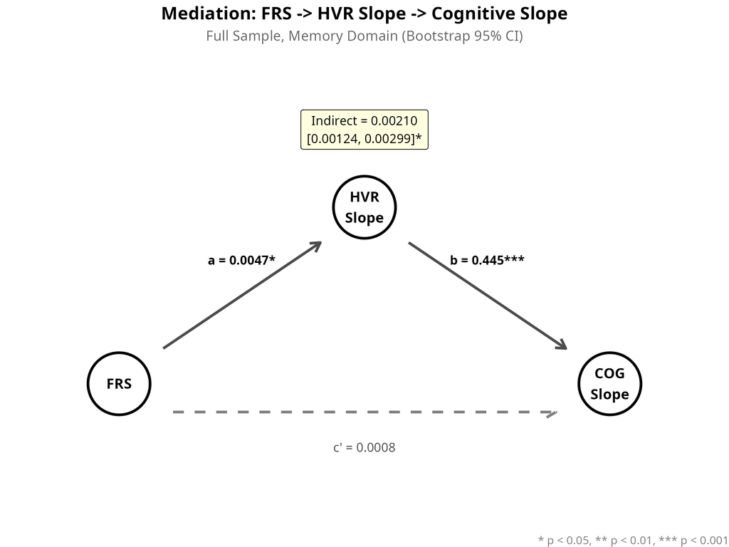

**Two parallel processes**

- HVR latent intercept + slope
- Cog latent intercept + slope

**Time metric**

- **Individually-varying EDT**
- Fixed-quadratic phantom factors

**Estimation**

- FIML · OpenMx + SLSQP
- Cog residual variance fixed to **SE²**

Bollen & Curran, 2006 · Muñiz-Terrera et al., 2017 · Neale et al., 2016

Chapter 6 · Simulation validation

SE-constrained residuals work

**Why constrain residuals to SE²?**

- ADSP-PHC CFA produces **observation-specific SEs**
- Freely estimating residuals discards this information
- Constraint leverages known measurement error

**Simulation setup**

- 9 conditions × 1,000 reps each
- SE-constrained vs free-residual
- Outcomes: convergence, bias, RMSE, 95% coverage

**Results (N = 200 example)**

- Convergence: **500/1000** reps (both methods)
- RMSE: **0.006** (both methods)
- 95% CI coverage:  
  93.8% (SE) vs 93.4% (free)
- Bias near zero in both

**Verdict**

Performance is **equivalent** —  
the SE‑constraint trades a tiny efficiency gain  
for the principled use of measurement error.

Bollen & Curran, 2006 · Appendix B simulation

Chapter 6 · Inference

Why bias-corrected bootstrap

**The indirect effect (a · b)**

- Product of two coefficients
- Sampling distribution is **skewed**
- Sobel test assumes normality — known to be conservative

**Bias-corrected bootstrap**

- Adjusts for skewness in the bootstrap distribution
- Standard for mediation since MacKinnon et al.
- N = 1,000 resamples

**Paired Δ_a bootstrap**

- Same seed across FRS and CVR_mimic
- Enables formal predictor comparison (Slide 21)

Efron & Tibshirani, 1994

Chapter 6 · The b-path

HVR-cognitive coupling is robust to CVR measure

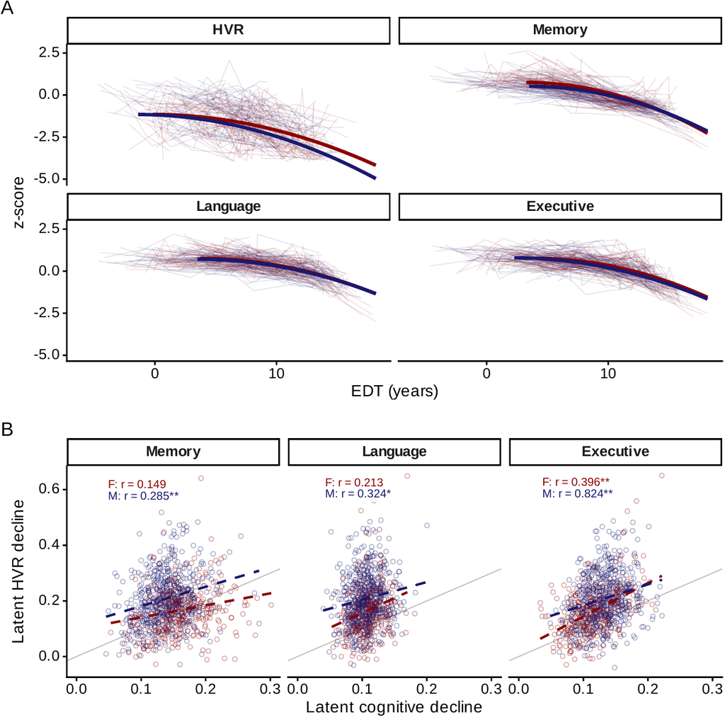

HVR-slope × cognitive-slope correlations sig in **4 of 6** sex × domain cells for both FRS and CVR<sub>mimic</sub> models.  
Coupling is the **predictor-agnostic finding** — a neurodegenerative signal, not driven by age confound.

Kramer et al., 2007 · Oschwald et al., 2020 · Anblagan et al., 2018

Chapter 6 · The money slide

FRS a-paths bold;  
CVR<sub>mimic</sub> a-paths faded

b-paths bold for both predictors

Rows are cognitive domains  
(Memory, Language, Executive).  
Columns are FRS vs CVR<sub>mimic</sub>.

Each panel shows male (blue)  
and female (red) path coefficients.

**Bold** = bootstrap 95% CI excludes zero.

**Pattern**

FRS a-paths bold across the board;  
CVR<sub>mimic</sub> a-paths faded (mostly n.s.);  
b-paths bold in both columns.

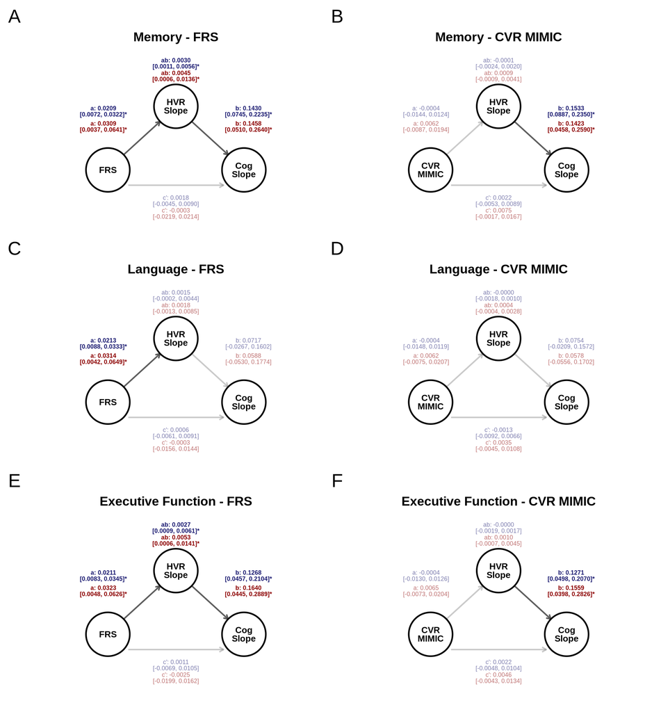

Chapter 6 · Formal a-path comparison

Paired Δa — FRS > CVR_mimic a-path

**Bootstrap setup**

- Same seed across FRS / CVR_mimic models
- Δa = a_FRS − a_CVR per individual
- Bias-corrected 95% CI

**Results (sign)**

- **Males**: Δa positive across MEM, LAN, EXF
- Females: Δa positive in LAN, narrowly include zero in MEM + EXF

**Why this slide**

- Upgrades the “FRS a-paths bold, CVR_mimic faded” pattern to a formal paired test
- Pre-empts “you eye-balled it”

Efron & Tibshirani, 1994

Chapter 6 · Multiple testing

12 LGCM × 12 LME — how to handle?

**Two principled positions**

- **LME**: FDR within predictor (6 tests = 3 domains × 2 sex); FRS and CVR_mimic corrected separately (distinct hypotheses)
- **LGCM**: inference rests on the **pattern of dissociation** across 12 tests, not any single test

**Sensitivity**

**Pre-empt**

- Conservative correction would not change conclusions
- Pattern argument is robust to per-test correction

Rothman, 1990 · Perneger, 1998

Chapter 6 · Strongest sensitivity result

A−/CU control: the pattern reverses

**A−/CU sub-sample**

- Amyloid-negative, cognitively unimpaired participants within UKB age range
- Independent sensitivity sample
- No AD pathology

**Pattern in A−/CU**

**Interpretation**

- In A+, FRS effects are carried by age × AD pathology covariation
- In A−/CU, age × pathology link weak → genuine residual CV signal emerges
- Supports a specificity interpretation over cherry-picking

Chapter 6 · HVR vs HC sensitivity

HVR > HC for moderation

**3-way interaction count**

[output not shown]

**Raw HVR** (no UKB normalization) shows similar pattern to z-scored HVR — supports specificity.

**Why HVR wins**

- Captures HC + LV jointly — ventricular component carries additional moderation signal
- Pre-empts “you cherry-picked HVR”

Schoemaker et al., 2019 · Fernandez-Lozano et al., 2025 · Bruno 2016

Chapter 6 · Normative transfer validation

UKB → ADNI z-score transfer (with calibration caveat)

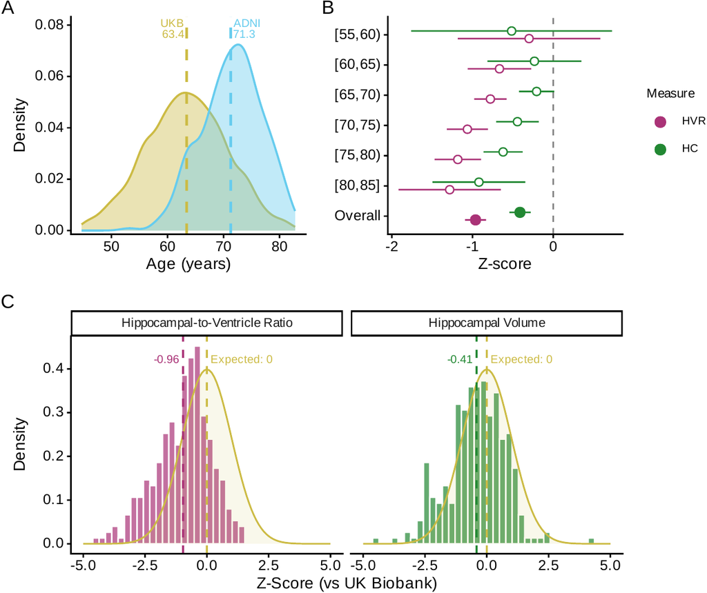

Sliwinski et al., 2010 · Hoffman & Stawski, 2009

Chapter 6 · Sex differences

Sex-specific results  
and the one CVR<sub>mimic</sub> positive

**FRS sex asymmetry**

- Female FRS ceiling rates higher (variance compression)
- Male FRS coefficient **3.06**; female **2.33** (D’Agostino 2008)

**The one CVR<sub>mimic</sub> positive**

- Female **Executive Function** survives FDR
- Consistent with Villeneuve 2011  
  — vascular burden selectively impairs EF in MCI

**Δa larger in females**

- Female Δa estimates larger than male  
  across MEM, LAN, EXF
- Dissociation more pronounced  
  in females

Ferretti et al., 2018 · Mielke 2022 · Villeneuve et al., 2011

Chapter 6 · Attrition

Selective dropout makes FRS findings conservative

**Completers vs dropouts**

- Dropouts had **higher baseline FRS**
- Selective loss of higher-CV-risk participants
- Direction of bias: **attenuates** observed CV effects

**Implication**

- FRS LME / LGCM effects are conservative estimates
- True association may be stronger
- CVR_mimic null findings unlikely to be inflated by attrition

**Mitigations**

- FIML estimation in LGCM (partial-data participants retained)
- Sensitivity analysis on completers only — similar pattern

Chapter 6 · Interpretation

Moderation without mediation  
— reserve mechanism

**The puzzle**

- CVR<sub>mimic</sub> a-path (LGCM) = 0  
  → no acceleration of HVR atrophy
- But LME 3-way interactions emerge  
  in some Female CVR<sub>mimic</sub> models
- How can it moderate without mediating?

**Reserve interpretation**

- Residual CV burden may reduce **capacity**  
  to maintain cognition at a given structural level
- A reserve-like mechanism  
  distinct from neurodegeneration

**Supporting evidence**

- A−/CU reversal (Slide 23) consistent with this
- Significant CVR<sub>mimic</sub> *c’* direct effects  
  in some female domains
- Frames cognitive reserve  
  as biologically tractable

Stern, 2012 · Rabin et al., 2018 · Iadecola, 2020

Chapter 6 · Limitations

What this chapter does not claim

**Sample**

**Measurement**

- FRS 30% ceiling compresses variance
- 5-indicator MIMIC may be enriched
- Cross-sectional CVR measurement (single timepoint)

**Modeling**

- Fixed-quadratic LGCM constrains individual non-linearity (makes a-path null conservative)
- CFI/TLI/RMSEA not computable with individually-varying time scores

**Generalizability**

- WRAP, AIBL replication is future work

Grimm & Ram, 2016 · Mehta & West, 2000

Chapter 6 · Replication + extensions

What’s next

**Replication**

- WRAP, AIBL  
  — longitudinal CV measurement cohorts
- More diverse demographics

**Framework extensions**

- MIMIC age-adjustment generalizes  
  to any age-confounded composite  
  (PRS, lifestyle indices)
- Richer indicator panel  
  (amyloid as covariate?)

**Intervention trials**

- Test whether CV management  
  preserves HVR-cog coupling
- Use **age-adjusted CV endpoints**,  
  not raw FRS

Livingston et al., 2024

Chapter 6 · Indirect effect detail

FRS mediates 4 of 6; CVR<sub>mimic</sub> mediates none

**FRS indirect (a × b)**

**CVR<sub>mimic</sub> indirect**

- **0 of 6** models significant
- Confirms a-path null

- Memory: **β = −0.027**  
  (*p*<sub>FDR</sub> = 0.038)
- Language: **β = −0.040**  
  (*p*<sub>FDR</sub> = 0.009)
- EXF: **β = −0.060**  
  (*p*<sub>FDR</sub> < 0.001)

**CVR<sub>mimic</sub> exception**

Chapter 6 · Quantifying the confound

FRS-age *r* = 0.33 zero-order,  
0.36 partial

**FRS-age correlation (ADNI)**

- Zero-order: *r* = **0.326**
- Partial (other CVRFs controlled):  
  *r* = **0.358**
- Variance decomposition:
  - Age alone *R*² = **0.107**
  - CVRFs alone *R*² = **0.406**
  - Combined *R*² = **0.482**

**Ceiling compression**

- **28.1%** males at 30% FRS cap
- **74.9%** females at 30% cap
- 72.2% scored above 20% risk

**Implication**

- Age contribution is real but modest in *R*² terms
- Variance-compression is the bigger problem
- MIMIC residualizes **at the latent level**, not the observed

Chapter 6 · MIMIC model statistics

γ = 0.125  
— age explains 1.6% of latent CVR

**Fit indices (robust)**

| Index | Value | Threshold |
| --- | --- | --- |
| CFI | **1.000** | ≥ 0.95 |
| TLI | **1.020** | ≥ 0.95 |
| RMSEA | **0.000** | ≤ 0.06 |
| SRMR | **0.009** | ≤ 0.08 |

**Structural path**

- Age → latent CVR: γ = **0.125**
- *R*² = **0.016**
- → age explains **1.6%**  
  of latent CVR variance

**Interpretation**

CVR<sub>mimic</sub> is **largely age-free**  
at the latent level.

Latent factor captures cardiovascular  
signal independent of age.

Chapter 6 · HVR-cognition coupling detail

B-path: 4 of 6 in the mediation model

**Mediation b-path (LGCM)**

**Parallel-process coupling**

- Reported separately in chapter
- Language parallel-process coupling  
  reached significance in **males only**

**Why female b-paths are sparser**

- Smaller female longitudinal sub-sample  
  → lower power
- Executive Function carries  
  the female signal

**Why this matters**

- HVR-cognition coupling is the  
  **predictor-agnostic finding**  
  — robust to FRS vs CVR<sub>mimic</sub>
- Not 6/6, but pattern direction  
  is consistent across all panels

Chapter 6 · Age covariate asymmetry

Age → HVR sig in males, n.s. in females

**Males**

- Age → HVR intercept: **all 6** models significant
- Age → HVR slope: **all 6** significant
- Age coefficients larger in FRS than CVR<sub>mimic</sub> models

**Females**

- Age → HVR intercept: **all n.s.**
- Age → HVR slope: all n.s.

**Possible contributing factors**

- Smaller female longitudinal sub-sample → lower power
- FRS already absorbs much of the age signal  
  — covariate age competes for residual variance

**Not claimed**

- Definitive biological vs power attribution
- Pattern is reported, not formally tested as sex × age

**Why disclose** a committee will spot the asymmetry in path tables.

Chapter 6 · CVR measurement limit

CVR measured cross-sectionally  
— single timepoint

**The limitation (chapter)**

> CV risk measured **cross-sectionally**.

**What this means**

- HVR + cognition are longitudinal
- CVR is **single-timepoint**, baseline only
- Cannot test whether CVR *change*  
  predicts HVR slope

**Additional caveat**

- Values **compressed in upper range**  
  — limited dynamic range

**Mitigation**

- Baseline CVR proxies cumulative exposure
- Primary inference is baseline-CVR  
  → HVR trajectory (not Δ-on-Δ)
- Intervention trials would test causality

**Future work**

- Longitudinal CV cohorts (WRAP, AIBL)
- Richer MIMIC indicator panel

Chapter 6 · Reserve mechanism

Moderation without mediation  
— the reserve frame

**The pattern**

- CVR<sub>mimic</sub> a-path: **null**  
  (no acceleration of HVR atrophy)
- CVR<sub>mimic</sub> × HVR × time (LME 3-way):  
  **significant** in some female models
- → CVR<sub>mimic</sub> moderates without mediating

**Reserve framing**

> CV risk reduces **capacity to maintain**  
> cognition at a given structural level  
> — not by driving atrophy.

**Supporting evidence**

- A⁻/CU reversal — CVR<sub>mimic</sub> sig where FRS isn’t
- Female CVR<sub>mimic</sub> *c’* effects (some domains)
- Frames CVR as a **reserve-like factor**

**Distinct from neurodegeneration**

- Not via atrophy acceleration
- Distinct from amyloid / tau cascade — modifiable

Stern, 2012 · Rabin et al., 2018 · Iadecola, 2020

Chapter 6 · Mechanistic closure

A−/CU LGCM  
— null a-paths, preserved b-paths

**a-paths (predictor → HVR slope)**

| Domain | FRS β · *p* | CVR<sub>mimic</sub> β · *p* |
| --- | --- | --- |
| Memory | 0.005 · 0.560 | 0.002 · 0.759 |
| Language | 0.005 · 0.546 | 0.002 · 0.792 |
| EXF | 0.005 · 0.582 | 0.002 · 0.804 |

a-path estimates near zero  
— **genuinely null**, not power-limited.

**b-paths (HVR → cognition)**

- Memory: **β = 0.356** · *p* = 0.003
- EXF: **β = 0.283** · *p* = 0.034
- Language: β = 0.307 · *p* = 0.051  
  (borderline)

**Indirect (Sobel)**

- All *p* > 0.5 — no mediation

**Closure** FRS mediates only when age co-varies with **AD pathology**; coupling persists.

Appendix C · A−/CU LGCM table

Chapter 6 · Selective dropout — directional bias

Dropouts had higher baseline FRS and APOE ε4

**Baseline (completers vs dropouts)**

|  | Completers | Dropouts | *p* |
| --- | --- | --- | --- |
| FRS | −0.04 | **0.22** | < 0.001 |
| APOE ε4 (%) | 58.1 | **65.5** | 0.038 |
| HVR z | −2.03 | −2.26 | 0.051 |
| Sex (% M) | 56.2 | 54.3 | 0.64 |
| Age | 73.7 | 74.3 | 0.32 |

**Logistic regression (dropout)**

- FRS: **OR = 1.52**  
  [1.26, 1.84]
- APOE ε4: **OR = 1.37**  
  [1.02, 1.86]

**Direction of bias**

**Implication**

Selective dropout would **attenuate**  
the FRS effects we report  
→ **conservative estimates**.

Appendix C · attrition baseline table

Chapter 6 · Robustness to normative z-scoring

Raw HVR effects survive  
— z-scoring isn’t driving findings

**Raw HVR (no UKB z-scoring)**

| Domain | β | *p* |
| --- | --- | --- |
| Memory | **−0.0162** | **0.003** |
| Language | **−0.0133** | **0.042** |
| EXF | **−0.0200** | **0.005** |

All three **significant**  
— same direction as z-scored HVR.

**Raw HC + TIV covariate**

- Memory: β = −0.013, *p* = 0.10 (n.s.)
- Language: β = −0.008, *p* = 0.30 (n.s.)
- EXF: **β = −0.017, *p* = 0.017** (sig)

**Takeaway**

- Raw HVR replicates z-scored pattern; HC + TIV weaker
- z-scoring **enhances sensitivity**  
  but the effect lives in the raw measure

Appendix C · raw measure sensitivity